# 5. Dimensionality reduction techniques

## Graphical overview and summaries

```r
library(corrplot)
library(dplyr)
library(ggplot2)
library(tidyr)
library(GGally)
human <- read.csv(file ="~/IODS-project/data/human.csv", row.names = 1)
summary(human)
```

```
##      edu2FM           labFM           lifeExp       educationExp
##  Min.   :0.1717   Min.   :0.1857   Min.   :49.00   Min.   : 5.40
##  1st Qu.:0.7264   1st Qu.:0.5984   1st Qu.:66.30   1st Qu.:11.25
##  Median :0.9375   Median :0.7535   Median :74.20   Median :13.50
##  Mean   :0.8529   Mean   :0.7074   Mean   :71.65   Mean   :13.18
##  3rd Qu.:0.9968   3rd Qu.:0.8535   3rd Qu.:77.25   3rd Qu.:15.20
##  Max.   :1.4967   Max.   :1.0380   Max.   :83.50   Max.   :20.20
##       gni             matMor           birth           repParl
##  Min.   :   581   Min.   :   1.0   Min.   :  0.60   Min.   : 0.00
##  1st Qu.:  4198   1st Qu.:  11.5   1st Qu.: 12.65   1st Qu.:12.40
##  Median : 12040   Median :  49.0   Median : 33.60   Median :19.30
##  Mean   : 17628   Mean   : 149.1   Mean   : 47.16   Mean   :20.91
##  3rd Qu.: 24512   3rd Qu.: 190.0   3rd Qu.: 71.95   3rd Qu.:27.95
##  Max.   :123124   Max.   :1100.0   Max.   :204.80   Max.   :57.50
```

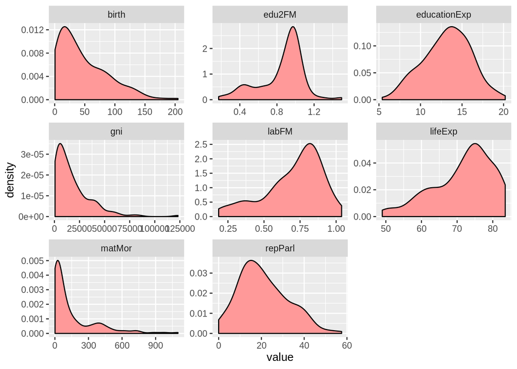

```r
ggplot(gather(human), aes(value)) + facet_wrap(~ key, scales = "free") + geom_density(fill="#FF9999", colour="black")
```

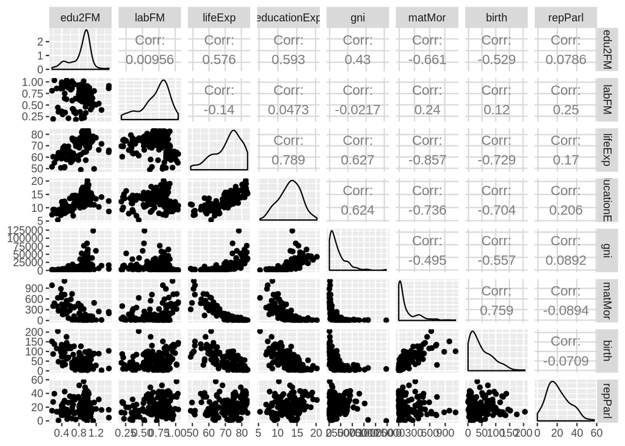

```r
ggpairs(human)
```

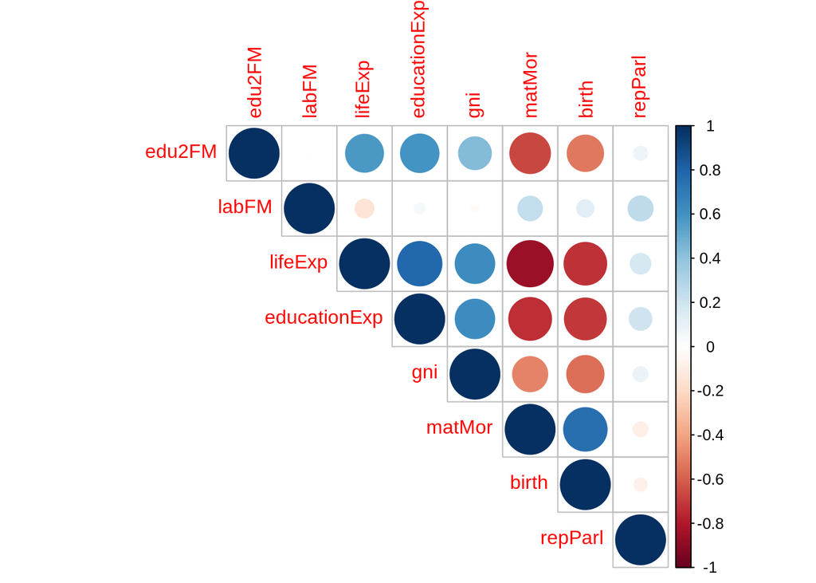

```r
cor(human) %>% corrplot(type = "upper")
```

## Performing Principal Component Analysis (PCA)

PCA on the not standardized human data

[output not shown]

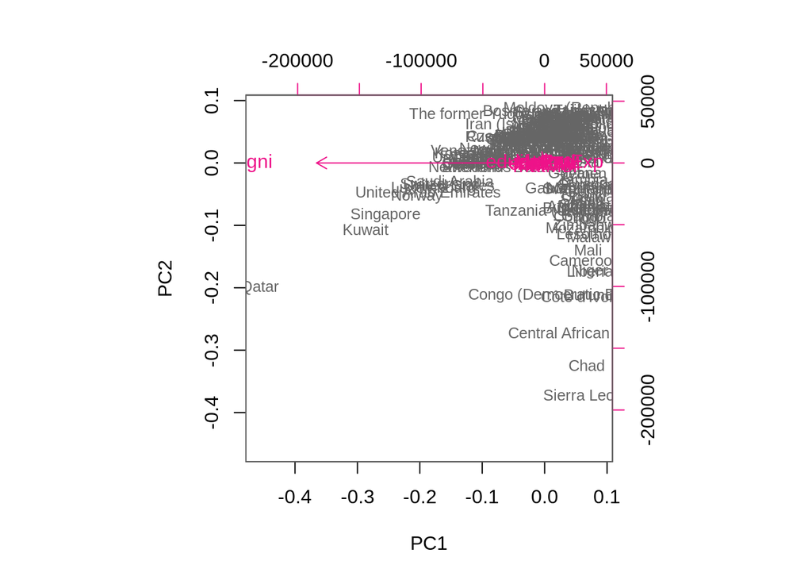

```r
pca_human <- prcomp(human)
biplot(pca_human, choices = 1:2, cex = c(0.8, 1), col = c("grey40", "deeppink2"))
```

Because the PCA is supposed to be done with standardized values, we get some warnings. The results we obtain are related to the scale of the values. Higher scales (like in the case of the GNI index that we modified) results in higher relevance in the plot.

## Performing Principal Component Analysis (PCA) with standardized values

```r
# We standardized the variables
human_std <- scale(human)
pca_humanstd <- prcomp(human_std)
s <- summary(pca_humanstd)
s
```

```
## Importance of components:
##                           PC1    PC2     PC3     PC4     PC5     PC6     PC7
## Standard deviation     2.0708 1.1397 0.87505 0.77886 0.66196 0.53631 0.45900
## Proportion of Variance 0.5361 0.1624 0.09571 0.07583 0.05477 0.03595 0.02634
## Cumulative Proportion  0.5361 0.6984 0.79413 0.86996 0.92473 0.96069 0.98702
##                            PC8
## Standard deviation     0.32224
## Proportion of Variance 0.01298
## Cumulative Proportion  1.00000
```

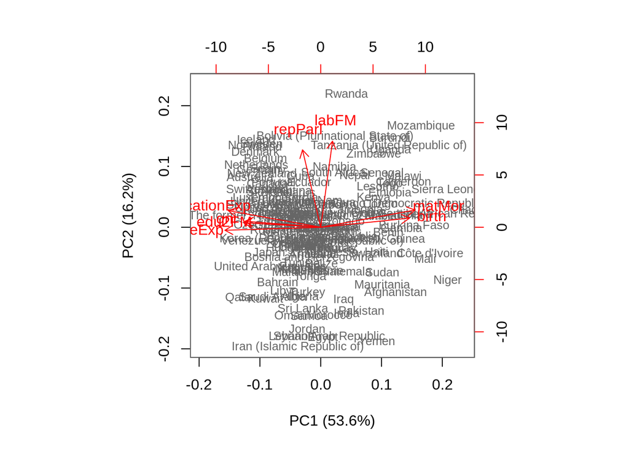

```r
pca_pr <- round(100*s$importance[2, ], digits = 1)
pc_lab <- paste0(names(pca_pr), " (", pca_pr, "%)")
biplot(pca_humanstd, cex = c(0.8, 1), col = c("grey40", "red"), xlab = pc_lab[1], ylab = pc_lab[2])
```

As we mentioned, it was impossible to observe useful information from the biplot with the non-standardized values. However, with this new biplot, we are able to see clearly some information. We observe, for example, how the first Principal Component, situated in the X axis, correposponds to the 53.6% of the total variance, while the second Principal Component, situated in the Y axis, correspondes to the 16,2% of the total variance in the original variables.  
We can also observe how the original variables are easily distributed in two directions (almost in parallel to the axis). For example, repPar and labFM are in the same direction than the PC2, while the other variables are in the direction of the PC1. We also see how the angles between the variables have for the most part small angles between each, which demonstrates a high correlation (this correlation can be positive or negative).  
Being more specific, we can observe how the maternal mortality is highly correlated with the adolescent birth rate. We also observe how the ratio of female workers over men is linked with the number of female parliamentary representatives. And we can conclude also that these two variables have no correlation with the maternal mortality or the adolescent birth rate. Finally, we can observe how the life expectancy, the expected education levels, the GNI ratio or the ratio of female over male education have a high degree of positive correlation with each other and have a strong negative correlation with the adolescent birth rate and maternal mortality rate.

## Interpretation of components

The first Principal Component seems to represent a value of the general health and life conditions and gender equality in the domestic sphere.  
On the other hand, the second Principal Component seems to represent the integration of women in the public sphere (politics and jobs).

## Multiple Correspondence Analysis

```r
library(FactoMineR)
data(tea)
str(tea)
```

```
## 'data.frame':    300 obs. of  36 variables:
##  $ breakfast       : Factor w/ 2 levels "breakfast","Not.breakfast": 1 1 2 2 1 2 1 2 1 1 ...
##  $ tea.time        : Factor w/ 2 levels "Not.tea time",..: 1 1 2 1 1 1 2 2 2 1 ...
##  $ evening         : Factor w/ 2 levels "evening","Not.evening": 2 2 1 2 1 2 2 1 2 1 ...
##  $ lunch           : Factor w/ 2 levels "lunch","Not.lunch": 2 2 2 2 2 2 2 2 2 2 ...
##  $ dinner          : Factor w/ 2 levels "dinner","Not.dinner": 2 2 1 1 2 1 2 2 2 2 ...
##  $ always          : Factor w/ 2 levels "always","Not.always": 2 2 2 2 1 2 2 2 2 2 ...
##  $ home            : Factor w/ 2 levels "home","Not.home": 1 1 1 1 1 1 1 1 1 1 ...
##  $ work            : Factor w/ 2 levels "Not.work","work": 1 1 2 1 1 1 1 1 1 1 ...
##  $ tearoom         : Factor w/ 2 levels "Not.tearoom",..: 1 1 1 1 1 1 1 1 1 2 ...
##  $ friends         : Factor w/ 2 levels "friends","Not.friends": 2 2 1 2 2 2 1 2 2 2 ...
##  $ resto           : Factor w/ 2 levels "Not.resto","resto": 1 1 2 1 1 1 1 1 1 1 ...
##  $ pub             : Factor w/ 2 levels "Not.pub","pub": 1 1 1 1 1 1 1 1 1 1 ...
##  $ Tea             : Factor w/ 3 levels "black","Earl Grey",..: 1 1 2 2 2 2 2 1 2 1 ...
##  $ How             : Factor w/ 4 levels "alone","lemon",..: 1 3 1 1 1 1 1 3 3 1 ...
```

[output cut: 22 more lines]

```r
dim(tea)
```

```
## [1] 300  36
```

```r
keep_columns <- c("Tea", "How", "how", "sugar", "where", "lunch","pub","always")
tea_time <- select(tea, one_of(keep_columns))
str(tea_time)
```

```
## 'data.frame':    300 obs. of  8 variables:
##  $ Tea   : Factor w/ 3 levels "black","Earl Grey",..: 1 1 2 2 2 2 2 1 2 1 ...
##  $ How   : Factor w/ 4 levels "alone","lemon",..: 1 3 1 1 1 1 1 3 3 1 ...
##  $ how   : Factor w/ 3 levels "tea bag","tea bag+unpackaged",..: 1 1 1 1 1 1 1 1 2 2 ...
##  $ sugar : Factor w/ 2 levels "No.sugar","sugar": 2 1 1 2 1 1 1 1 1 1 ...
##  $ where : Factor w/ 3 levels "chain store",..: 1 1 1 1 1 1 1 1 2 2 ...
##  $ lunch : Factor w/ 2 levels "lunch","Not.lunch": 2 2 2 2 2 2 2 2 2 2 ...
##  $ pub   : Factor w/ 2 levels "Not.pub","pub": 1 1 1 1 1 1 1 1 1 1 ...
##  $ always: Factor w/ 2 levels "always","Not.always": 2 2 2 2 1 2 2 2 2 2 ...
```

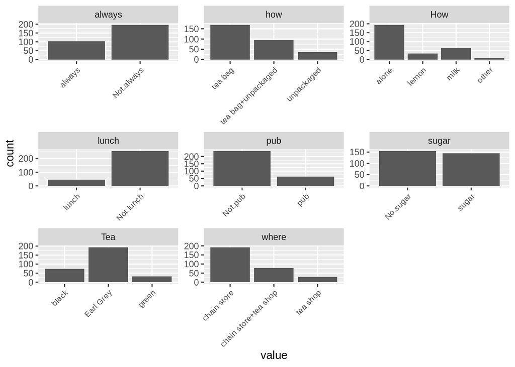

```r
gather(tea_time) %>% ggplot(aes(value)) + facet_wrap("key", scales = "free") + geom_bar() + theme(axis.text.x = element_text(angle = 45, hjust = 1, size = 8))
```

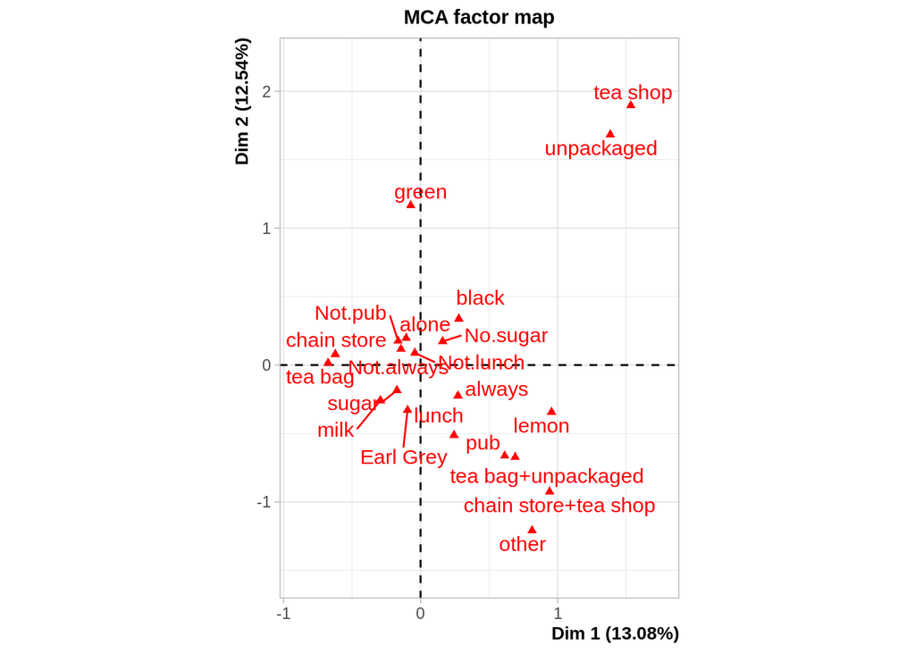

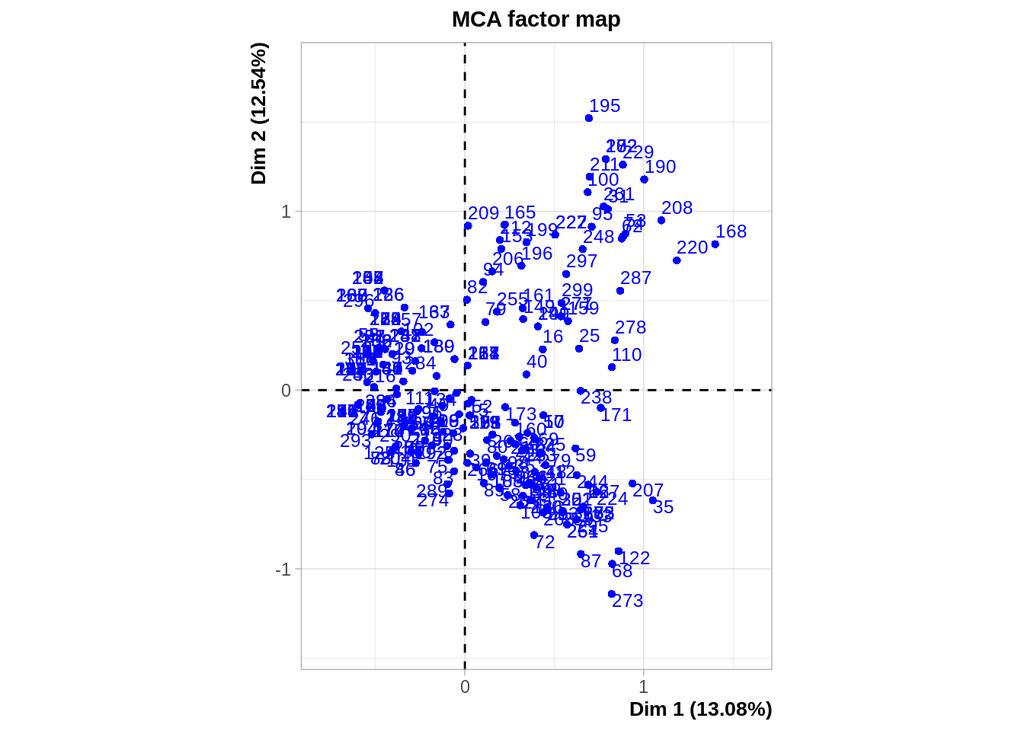

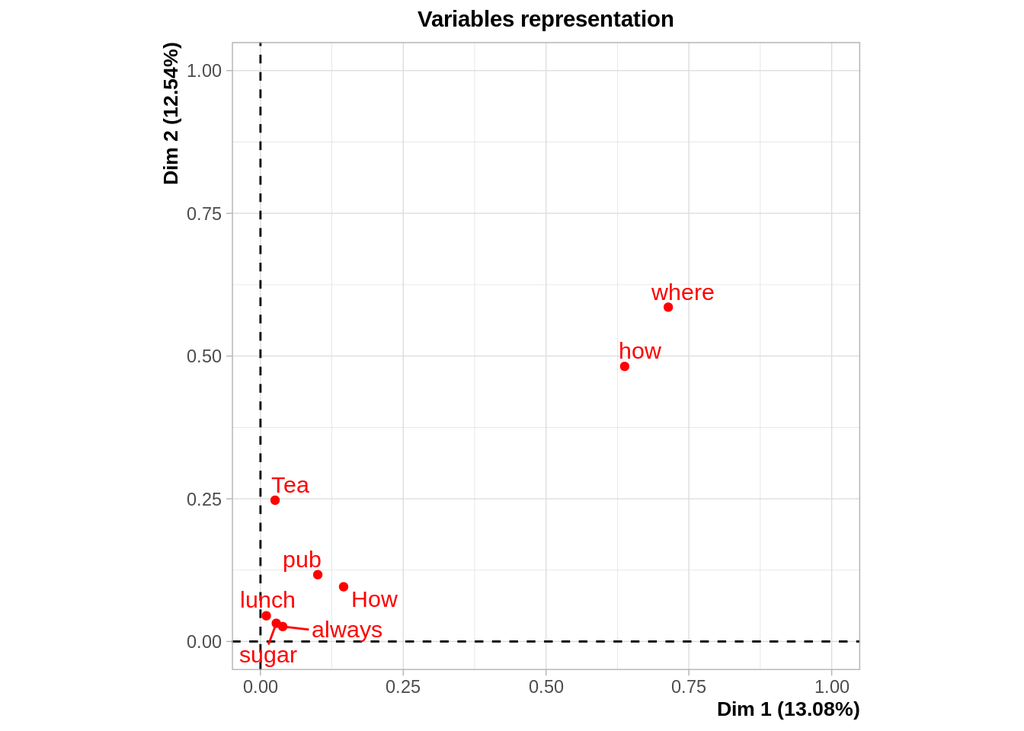

```r
mca <- MCA(tea_time, graph = TRUE)
```

```r
summary(mca)
```

```
##
## Call:
## MCA(X = tea_time, graph = TRUE)
##
##
## Eigenvalues
##                        Dim.1   Dim.2   Dim.3   Dim.4   Dim.5   Dim.6   Dim.7
## Variance               0.212   0.204   0.173   0.147   0.141   0.127   0.120
## % of var.             13.076  12.545  10.654   9.025   8.682   7.814   7.371
## Cumulative % of var.  13.076  25.621  36.275  45.300  53.982  61.796  69.167
##                        Dim.8   Dim.9  Dim.10  Dim.11  Dim.12  Dim.13
## Variance               0.106   0.106   0.093   0.086   0.063   0.046
## % of var.              6.546   6.518   5.737   5.293   3.880   2.858
## Cumulative % of var.  75.714  82.232  87.969  93.262  97.142 100.000
##
## Individuals (the 10 first)
##                       Dim.1    ctr   cos2    Dim.2    ctr   cos2    Dim.3
## 1                  | -0.446  0.311  0.228 |  0.229  0.086  0.060 |  0.250
## 2                  | -0.406  0.259  0.131 |  0.202  0.067  0.033 |  0.656
## 3                  | -0.457  0.327  0.387 |  0.143  0.033  0.038 |  0.110
## 4                  | -0.547  0.469  0.538 |  0.044  0.003  0.004 | -0.210
## 5                  | -0.344  0.186  0.166 |  0.049  0.004  0.003 | -0.119
## 6                  | -0.457  0.327  0.387 |  0.143  0.033  0.038 |  0.110
## 7                  | -0.457  0.327  0.387 |  0.143  0.033  0.038 |  0.110
## 8                  | -0.406  0.259  0.131 |  0.202  0.067  0.033 |  0.656
## 9                  |  0.287  0.129  0.058 | -0.451  0.333  0.145 |  0.461
## 10                 |  0.439  0.303  0.147 | -0.141  0.032  0.015 |  0.835
##                       ctr   cos2
## 1                   0.120  0.072 |
## 2                   0.829  0.343 |
## 3                   0.023  0.022 |
## 4                   0.085  0.079 |
## 5                   0.027  0.020 |
## 6                   0.023  0.022 |
## 7                   0.023  0.022 |
## 8                   0.829  0.343 |
## 9                   0.410  0.151 |
## 10                  1.342  0.530 |
##
## Categories (the 10 first)
```

[output cut: 18 more lines]

```
## other               -3.675 |   2.426  12.753   0.182   7.379 |
## tea bag              0.306 |  -0.106   0.459   0.015  -2.095 |
## tea bag+unpackaged  -7.856 |   0.350   2.772   0.056   4.089 |
## unpackaged          10.748 |  -0.414   1.482   0.023  -2.641 |
##
## Categorical variables (eta2)
##                      Dim.1 Dim.2 Dim.3
## Tea                | 0.026 0.247 0.418 |
## How                | 0.146 0.096 0.276 |
## how                | 0.638 0.482 0.065 |
## sugar              | 0.028 0.032 0.283 |
## where              | 0.714 0.586 0.102 |
## lunch              | 0.010 0.045 0.013 |
## pub                | 0.100 0.117 0.097 |
## always             | 0.039 0.026 0.131 |
```

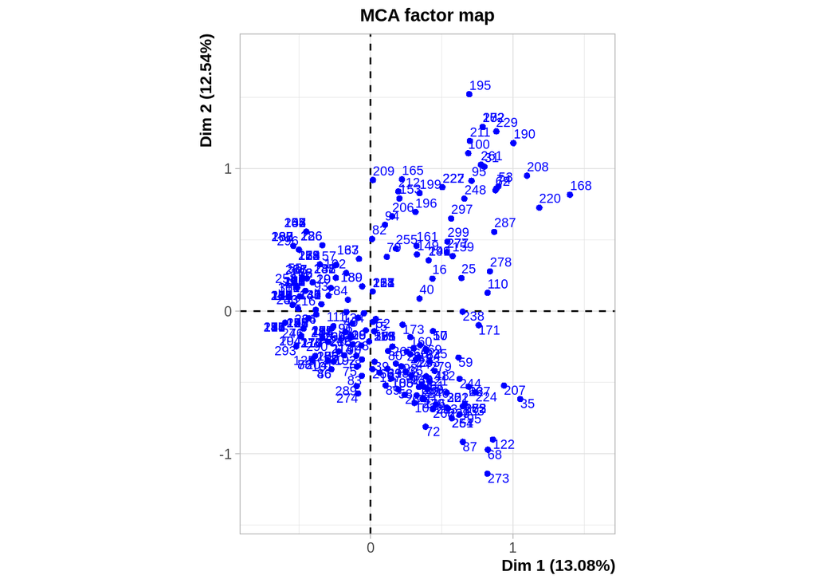

```r
plot.MCA(mca, invisible=c("var","quali.sup"), cex=0.7)
```

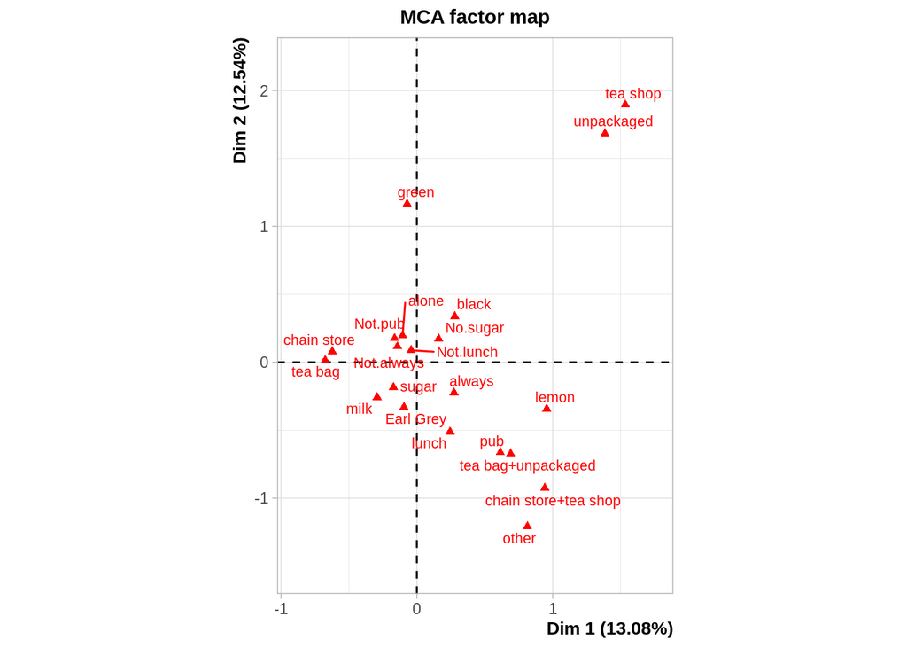

```r
plot.MCA(mca, invisible=c("ind"), cex=0.7)
```

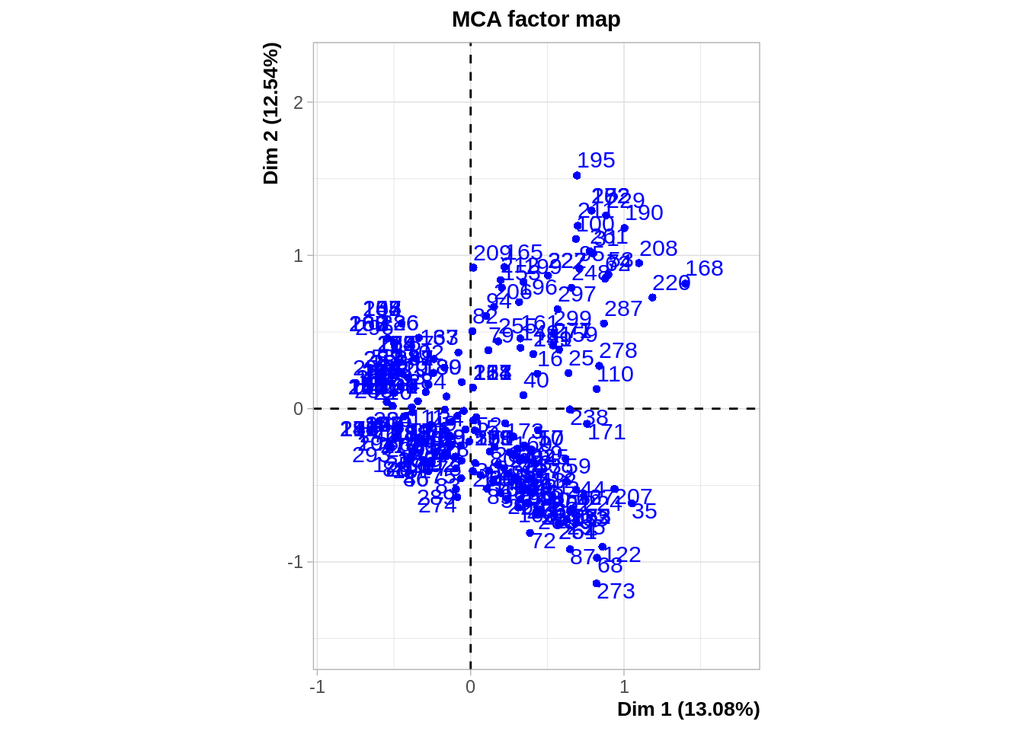

```r
plot(mca, invisible=c("quali.sup"), habillage= "quali")
```

We can observe in the different plots the variables that define the created dimensions. We also observe the relation between the different variables. The variables that are closer in the space in the plot representation have higher correlation. For instance, in the first MCA factor map, we see how the values **tea shop** and **unpackaged** are closer to each other than to any other value. This explaine the connection that they have.